# problem2

```python
import pandas as pd
import numpy as np
import matplotlib.pyplot as plt
from fbprophet import Prophet
from fbprophet.diagnostics import cross_validation
from fbprophet.diagnostics import performance_metrics
from fbprophet.plot import add_changepoints_to_plot
import itertools
from statsmodels.tsa.holtwinters import ExponentialSmoothing
from sklearn.model_selection import TimeSeriesSplit
np.random.seed(777)
```

```
Importing plotly failed. Interactive plots will not work.
```

```python
def rmse(predictions, targets):
    return np.sqrt(np.mean((predictions - targets) ** 2))
```

```python
days = 7 # Days to forecast
```

```python
df = pd.read_csv('part_2_timeseries_(2).csv', parse_dates=['invoice_date'], skip_blank_lines=True, header=0)
# Check data
df.info()
```

```
<class 'pandas.core.frame.DataFrame'>
RangeIndex: 671 entries, 0 to 670
Data columns (total 2 columns):
 #   Column        Non-Null Count  Dtype
---  ------        --------------  -----
 0   invoice_date  95 non-null     datetime64[ns]
 1   net_weight    95 non-null     float64
dtypes: datetime64[ns](1), float64(1)
memory usage: 10.6 KB
```

```python
df # Erroneously reading in many NA rows at end
```

|  | invoice_date | net_weight |
| --- | --- | --- |
| 0 | 2015-03-05 | 131.0 |
| 1 | 2015-03-06 | 164.0 |
| 2 | 2015-03-07 | 187.0 |
| 3 | 2015-03-08 | 235.0 |
| 4 | 2015-03-09 | 213.0 |
| ... | ... | ... |
| 666 | NaT | NaN |
| 667 | NaT | NaN |
| 668 | NaT | NaN |
| 669 | NaT | NaN |
| 670 | NaT | NaN |

671 rows × 2 columns

```python
# Check if there are any gaps in days (are any days missing?)
assert pd.date_range(df['invoice_date'].min(), df['invoice_date'].max()).difference(df['invoice_date']).shape[0] == 0
```

```python
# After prior check, drop NA rows
df = df.dropna()
df.info()
df = df.rename(columns={df.columns[0]: 'ds', df.columns[1]: 'y'}) # Preparing for Prophet
```

```
<class 'pandas.core.frame.DataFrame'>
Int64Index: 95 entries, 0 to 94
Data columns (total 2 columns):
 #   Column        Non-Null Count  Dtype
---  ------        --------------  -----
 0   invoice_date  95 non-null     datetime64[ns]
 1   net_weight    95 non-null     float64
dtypes: datetime64[ns](1), float64(1)
memory usage: 2.2 KB
```

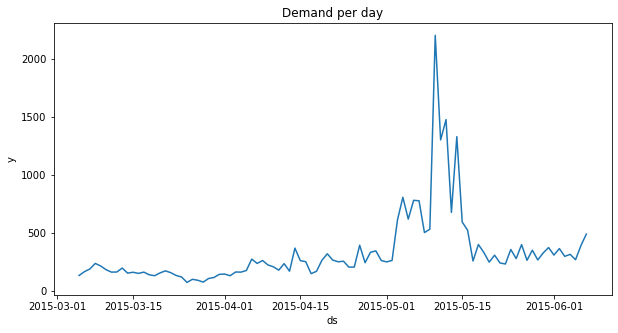

```python
# Visual inspection
plt.figure(figsize=(10,5))
plt.title('Demand per day')
plt.xlabel(str(df.columns[0]))
plt.ylabel(str(df.columns[1]))
plt.plot(df[df.columns[0]], df[df.columns[1]])
plt.show()
```

We are only looking at 3 months but there is:

1. Evidence to a general base level of demand around the ~200 net_weight level
2. Potentially a positive trend in the baseline (excluding May)
3. Large spike in second week of May that warrants further explanation
   - One-time promotion without lasting effects?
   - Or evidence of some type of seasonality?
   - Can examine treating as both outlier/non-outlier

```python
# Running Prophet

# Using Cross Validation to find best model

param_grid = {
    'changepoint_prior_scale': [0.01, 0.05, 0.1, 1, 10],
    'seasonality_prior_scale': [0.01, 1, 10],
}

all_params = [dict(zip(param_grid.keys(), v)) for v in itertools.product(*param_grid.values())]
scores = pd.DataFrame()

# Use cross validation to evaluate all parameters
for params in all_params:
    m = Prophet(**params).fit(df)  # Fit model with given params
    df_cv = cross_validation(m, initial='7 days', period='7 days', horizon = '7 days', parallel="processes")
    df_p = performance_metrics(df_cv, rolling_window=1)
    scores = scores.append(df_p)

# Find the best parameters
tuning_results = pd.concat([pd.DataFrame(all_params).reset_index(drop=True), scores.reset_index(drop=True)],axis=1)
print(tuning_results)
best_params = all_params[np.argmin(tuning_results['rmse'])] # Using RMSE as metric to select best hyperparameters
```

[output not shown]

[output cut: 20 more lines]

```
    changepoint_prior_scale  seasonality_prior_scale horizon            mse  \
0                      0.01                     0.01  7 days  114713.948893
1                      0.01                     1.00  7 days  115258.812507
2                      0.01                    10.00  7 days  115098.890880
3                      0.05                     0.01  7 days  112200.961079
4                      0.05                     1.00  7 days  108287.801839
5                      0.05                    10.00  7 days  108487.021413
6                      0.10                     0.01  7 days  123496.320964
7                      0.10                     1.00  7 days  127597.049996
8                      0.10                    10.00  7 days  127807.102091
9                      1.00                     0.01  7 days  171241.624785
10                     1.00                     1.00  7 days  171608.205763
11                     1.00                    10.00  7 days  172490.725692
12                    10.00                     0.01  7 days  159547.016692
13                    10.00                     1.00  7 days  164810.765456
```

[output cut: 18 more lines]

```
INFO:fbprophet:Disabling yearly seasonality. Run prophet with yearly_seasonality=True to override this.
INFO:fbprophet:Disabling daily seasonality. Run prophet with daily_seasonality=True to override this.
```

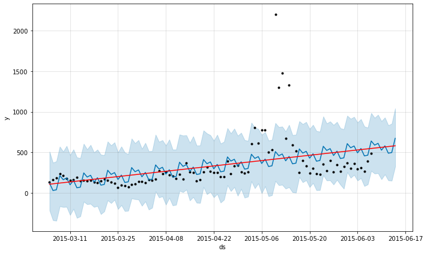

```python
model = Prophet(**best_params).fit(df)
future = model.make_future_dataframe(periods=days, freq='D')
forecast = model.predict(future)
fig = model.plot(forecast)
a = add_changepoints_to_plot(fig.gca(), model, forecast)
```

- The above is not accurately forecasting the latest bit of data (from May onwards), and the potential outliers in May are likely shifting the predictions higher than they should be
- We can try changing the time period Prophet considers from 80% of the data to a less conservative 90% and see what changes
- 7 day forecast is below

```python
forecast = forecast.assign(uncer_range=forecast['yhat_upper'] - forecast['yhat_lower'])
forecast[['ds', 'yhat', 'yhat_lower', 'yhat_upper', 'uncer_range']].tail(7)
```

|  | ds | yhat | yhat_lower | yhat_upper | uncer_range |
| --- | --- | --- | --- | --- | --- |
| 95 | 2015-06-08 | 589.855110 | 239.443849 | 925.329793 | 685.885944 |
| 96 | 2015-06-09 | 611.832919 | 244.008412 | 962.947328 | 718.938916 |
| 97 | 2015-06-10 | 527.258159 | 168.950693 | 884.360708 | 715.410015 |
| 98 | 2015-06-11 | 581.272157 | 229.859750 | 929.401054 | 699.541304 |
| 99 | 2015-06-12 | 490.234021 | 155.492828 | 833.373006 | 677.880178 |
| 100 | 2015-06-13 | 498.495348 | 151.656578 | 853.891152 | 702.234574 |
| 101 | 2015-06-14 | 673.424399 | 325.929735 | 1041.553848 | 715.624113 |

```python
# Running less conservative Prophet

param_grid = {
    'changepoint_prior_scale': [0.01, 0.05, 0.1, 1, 10],
    'seasonality_prior_scale': [0.01, 1, 10],
    'changepoint_range': [0.90]
}

all_params = [dict(zip(param_grid.keys(), v)) for v in itertools.product(*param_grid.values())]
scores = pd.DataFrame()

# Use cross validation to evaluate all parameters
for params in all_params:
    m = Prophet(**params).fit(df)  # Fit model with given params
    df_cv = cross_validation(m, initial='7 days', period='7 days', horizon = '7 days', parallel="processes")
    df_p = performance_metrics(df_cv, rolling_window=1)
    scores = scores.append(df_p)

# Find the best parameters
tuning_results = pd.concat([pd.DataFrame(all_params).reset_index(drop=True), scores.reset_index(drop=True)],axis=1)
print(tuning_results)
best_params = all_params[np.argmin(tuning_results['rmse'])] # Using RMSE as metric to select best hyperparameters
```

[output not shown]

[output cut: 20 more lines]

```
    changepoint_prior_scale  seasonality_prior_scale  changepoint_range  \
0                      0.01                     0.01                0.9
1                      0.01                     1.00                0.9
2                      0.01                    10.00                0.9
3                      0.05                     0.01                0.9
4                      0.05                     1.00                0.9
5                      0.05                    10.00                0.9
6                      0.10                     0.01                0.9
7                      0.10                     1.00                0.9
8                      0.10                    10.00                0.9
9                      1.00                     0.01                0.9
10                     1.00                     1.00                0.9
11                     1.00                    10.00                0.9
12                    10.00                     0.01                0.9
13                    10.00                     1.00                0.9
```

[output cut: 35 more lines]

```
INFO:fbprophet:Disabling yearly seasonality. Run prophet with yearly_seasonality=True to override this.
INFO:fbprophet:Disabling daily seasonality. Run prophet with daily_seasonality=True to override this.
```

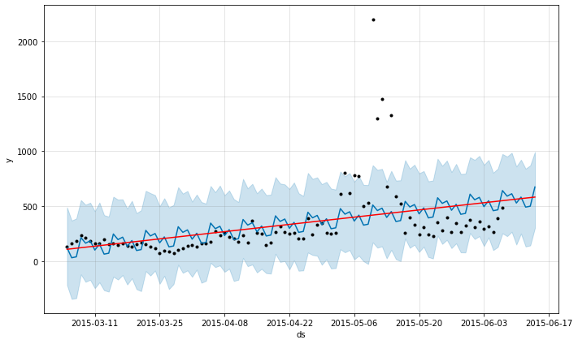

```python
model = Prophet(**best_params).fit(df)
forecast = model.predict(future)
fig = model.plot(forecast)
a = add_changepoints_to_plot(fig.gca(), model, forecast)
```

- No change in adding a longer changepoint consideration period
  - Still only one trend (no changepoints)
- In general the May spikes are forcing a more conservative prediction overall, rather than one that has more trend changes
  - We can remove this May spike period and investigate further

```python
# Examining data
df.loc[(df['ds'] > '2015-05-01') & (df['ds'] < '2015-05-20')]
```

|  | ds | y |
| --- | --- | --- |
| 58 | 2015-05-02 | 261.0 |
| 59 | 2015-05-03 | 609.0 |
| 60 | 2015-05-04 | 805.0 |
| 61 | 2015-05-05 | 617.0 |
| 62 | 2015-05-06 | 779.0 |
| 63 | 2015-05-07 | 775.0 |
| 64 | 2015-05-08 | 501.0 |
| 65 | 2015-05-09 | 530.0 |
| 66 | 2015-05-10 | 2201.0 |
| 67 | 2015-05-11 | 1300.0 |
| 68 | 2015-05-12 | 1475.0 |
| 69 | 2015-05-13 | 675.0 |
| 70 | 2015-05-14 | 1328.0 |
| 71 | 2015-05-15 | 592.0 |
| 72 | 2015-05-16 | 521.0 |
| 73 | 2015-05-17 | 256.0 |
| 74 | 2015-05-18 | 398.0 |
| 75 | 2015-05-19 | 330.0 |

```python
# Removed May spike

# Prophet handles missing values
subset_df = df.copy()
subset_df.loc[(subset_df['ds'] > '2015-05-02') & (subset_df['ds'] < '2015-05-17'), 'y'] = None

param_grid = {
    'changepoint_prior_scale': [0.01, 0.05, 0.1, 1, 10],
    'seasonality_prior_scale': [0.01, 1, 10],
    'changepoint_range': [0.90]
}

all_params = [dict(zip(param_grid.keys(), v)) for v in itertools.product(*param_grid.values())]
scores = pd.DataFrame()

# Use cross validation to evaluate all parameters
for params in all_params:
    m = Prophet(**params).fit(subset_df)  # Fit model with given params
    df_cv = cross_validation(m, initial='7 days', period='7 days', horizon = '7 days', parallel="processes")
    df_p = performance_metrics(df_cv, rolling_window=1)
    scores = scores.append(df_p)

# Find the best parameters
tuning_results = pd.concat([pd.DataFrame(all_params).reset_index(drop=True), scores.reset_index(drop=True)],axis=1)
print(tuning_results)
best_params = all_params[np.argmin(tuning_results['rmse'])] # Using RMSE as metric to select best hyperparameters
```

[output not shown]

[output cut: 20 more lines]

```
    changepoint_prior_scale  seasonality_prior_scale  changepoint_range  \
0                      0.01                     0.01                0.9
1                      0.01                     1.00                0.9
2                      0.01                    10.00                0.9
3                      0.05                     0.01                0.9
4                      0.05                     1.00                0.9
5                      0.05                    10.00                0.9
6                      0.10                     0.01                0.9
7                      0.10                     1.00                0.9
8                      0.10                    10.00                0.9
9                      1.00                     0.01                0.9
10                     1.00                     1.00                0.9
11                     1.00                    10.00                0.9
12                    10.00                     0.01                0.9
13                    10.00                     1.00                0.9
```

[output cut: 18 more lines]

```
INFO:fbprophet:Disabling yearly seasonality. Run prophet with yearly_seasonality=True to override this.
INFO:fbprophet:Disabling daily seasonality. Run prophet with daily_seasonality=True to override this.
```

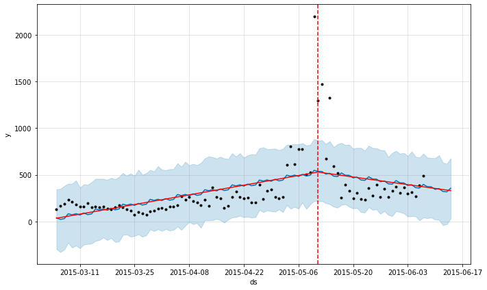

```python
sub_model = Prophet(**best_params).fit(df)
sub_forecast = sub_model.predict(future)
fig = sub_model.plot(sub_forecast)
a = add_changepoints_to_plot(fig.gca(), sub_model, sub_forecast)
```

```python
sub_forecast = sub_forecast.assign(uncer_range=sub_forecast['yhat_upper'] - sub_forecast['yhat_lower'])
sub_forecast[['ds', 'yhat', 'yhat_lower', 'yhat_upper', 'uncer_range']].tail(7)
```

|  | ds | yhat | yhat_lower | yhat_upper | uncer_range |
| --- | --- | --- | --- | --- | --- |
| 95 | 2015-06-08 | 373.030074 | 34.845703 | 685.007575 | 650.161873 |
| 96 | 2015-06-09 | 371.813788 | 41.460390 | 680.115882 | 638.655493 |
| 97 | 2015-06-10 | 344.147158 | 20.135913 | 679.099047 | 658.963135 |
| 98 | 2015-06-11 | 352.479134 | 16.573708 | 710.064516 | 693.490808 |
| 99 | 2015-06-12 | 321.803479 | -40.945047 | 630.754477 | 671.699523 |
| 100 | 2015-06-13 | 317.176292 | -30.560831 | 618.564333 | 649.125164 |
| 101 | 2015-06-14 | 356.268759 | 31.007011 | 677.786810 | 646.779800 |

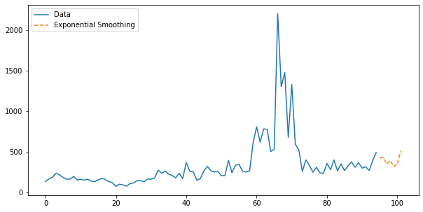

```python
# Exponential Smoothing
ef = future[-days:] # Get future points to predict

emodel = ExponentialSmoothing(np.array(df['y']), trend='add', seasonal='add', seasonal_periods=7).fit()
expForecast = emodel.predict(start=ef.index[-days], end=ef.index[-1])
expForecast = pd.DataFrame(expForecast, index=ef.index)

plt.figure(figsize=(10,5))
plt.plot(df['y'], label='Data')
plt.plot(expForecast, label='Exponential Smoothing', linestyle='--')
plt.legend(loc='upper left')
plt.show()
```

```python
expForecast
```

|  | 0 |
| --- | --- |
| 95 | 420.726336 |
| 96 | 427.313444 |
| 97 | 347.683494 |
| 98 | 389.482653 |
| 99 | 315.021973 |
| 100 | 350.985081 |
| 101 | 509.254887 |

```python
# Backtesting Exponential Smoothing
# Split into weeks
tscv = TimeSeriesSplit(13)

preds = []
errs = []
for train_index, test_index in tscv.split(df):
    #print("TRAIN:", train_index, "TEST:", test_index)
    y_train, y_test = df['y'][train_index], df['y'][test_index]
    expModel = ExponentialSmoothing(y_train, trend='add', seasonal='add', seasonal_periods=7).fit()
    expForecast = expModel.predict(start=y_test.index[0], end=y_test.index[-1])
    preds.append(expForecast)

    exp_err = rmse(expForecast, y_test)
    errs.append(exp_err)

expModel = ExponentialSmoothing(df['y'], trend='add', seasonal='add', seasonal_periods=7).fit()
expForecast = emodel.predict(start=ef.index[-days], end=ef.index[-1])
preds.append(expForecast)
preds = pd.DataFrame(np.concatenate(preds), index=range(preds[0].index.values[0], ef.index[-1]+1))
average_rmse = np.mean(errs)
print("RMSE over all periods: {}".format(average_rmse))
```

```
RMSE over all periods: 237.85085640970857
```

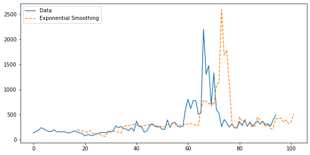

```python
plt.figure(figsize=(10,5))
plt.plot(df['y'], label='Data')
plt.plot(preds, label='Exponential Smoothing', linestyle='--')
plt.legend(loc='upper left')
plt.show()
```

- Exponential smoothing makes a drastic blunder in trying to catch up to the rise in demand, which turns out to be only a spike that returns to normal
- But overall catches back up to the recent trend faster than Prophet and its predictions outside the spike seem better
- Would warrant further investigation regarding this model without outliers - is likely better

If more time was available:

- Ideally sourcing more past data would be most helpful
  - With only 3 months we miss out on yearly seasonality and have a harder time distinguishing outliers
- Investigate case for sudden jump in May
  - Can appropriately change parameters of model to account for this
- Evaluate Exponential Smoothing model without outliers
- Potentially build an ensemble of models
  - Ranging from super conservative to faster adapting
  - A combination of these may successfully account for more variance than a single model